# Health and Economic Impacts of Severe Weather Events in the U.S.

Hailu Teju

July 21, 2017

## Synopsis

It is a well known fact that sever weather events have very harmful consequences in terms of human health and economic loses. Below, I will use the data obtained from the U.S. National Oceanic and Atmospheric Administration’s (NOAA) storm database and analyze the magnitudes of the damages caused by sever weather events in the U.S.

## Data Processing

I start by reading the raw data file which is in .csv.bz2 file format.

```r
library(dplyr)
library(ggplot2)
library(reshape2)

storm_data <- read.csv("repdata%2Fdata%2FStormData.csv.bz2")

dim(storm_data)
```

```
[1] 902297     37
```

The data set has 902,297 observations and 37 variables as it is shown above. Next, I choose only the subset of the data set that contains five of the 37 variables, the severe weather types (EVTYPE) and the damages caused by these weather types in human fatalities, injuries, property damage, and crop damage (the FATALITIES, INJURIES, PROPDMG, and CROPDMG columns, respectively, of the data frame).

```r
storm_damage <- storm_data %>% group_by(EVTYPE) %>% summarize_at(vars(FATALITIES, INJURIES, PROPDMG, CROPDMG),sum)

head(storm_damage)
```

[output not shown]

Next, I separate the damages caused on human health from those of economic loses.

I will start by analyzing the economic impact of sever weather events (property and crop damages).

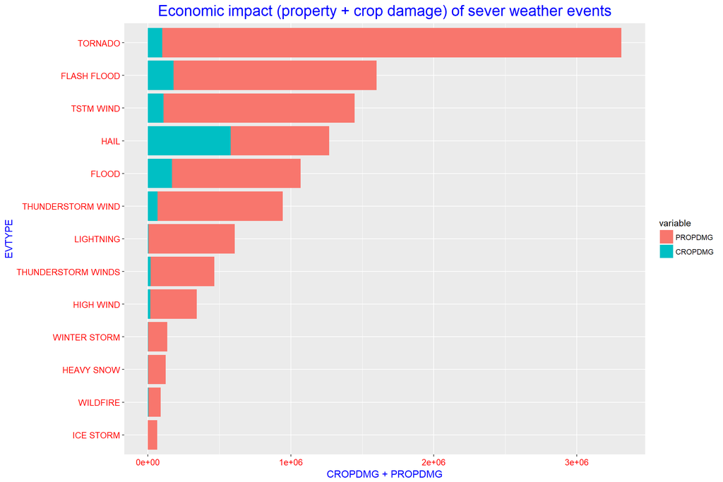

```r
storm_damage_economic <- storm_damage %>% select(EVTYPE, PROPDMG, CROPDMG) %>%  mutate(TOTECONDMG=PROPDMG + CROPDMG) %>% filter(TOTECONDMG > 0)

storm_damage_economic_m <- storm_damage_economic %>% melt(id=c("EVTYPE","TOTECONDMG"))

g <- ggplot(storm_damage_economic_m[order(-storm_damage_economic_m$TOTECONDMG),][1:25,], aes(x= reorder(EVTYPE,TOTECONDMG), y=value, fill=variable)) + geom_col() + coord_flip() + xlab("EVTYPE") + ylab("CROPDMG + PROPDMG")
g <- g + theme(axis.text = element_text(size=10, color="red"))
g <- g + theme(axis.title = element_text(size=12, color="blue"))
g <- g + ggtitle("Economic impact (property + crop damage) of sever weather events")
g <- g + theme(plot.title=element_text(color="blue", size= 18, hjust=0.5))

print(g)
```

```r
storm_damage_economic <- storm_damage_economic %>%  arrange(desc(TOTECONDMG))

head(storm_damage_economic, 15)
```

```
# A tibble: 15 x 4
               EVTYPE    PROPDMG   CROPDMG TOTECONDMG
               <fctr>      <dbl>     <dbl>      <dbl>
 1            TORNADO 3212258.16 100018.52 3312276.68
 2        FLASH FLOOD 1420124.59 179200.46 1599325.05
 3          TSTM WIND 1335965.61 109202.60 1445168.21
 4               HAIL  688693.38 579596.28 1268289.66
 5              FLOOD  899938.48 168037.88 1067976.36
 6  THUNDERSTORM WIND  876844.17  66791.45  943635.62
 7          LIGHTNING  603351.78   3580.61  606932.39
 8 THUNDERSTORM WINDS  446293.18  18684.93  464978.11
 9          HIGH WIND  324731.56  17283.21  342014.77
10       WINTER STORM  132720.59   1978.99  134699.58
11         HEAVY SNOW  122251.99   2165.72  124417.71
12           WILDFIRE   84459.34   4364.20   88823.54
13          ICE STORM   66000.67   1688.95   67689.62
14        STRONG WIND   62993.81   1616.90   64610.71
15         HEAVY RAIN   50842.14  11122.80   61964.94
```

Both of the graphics and the table above show some of the top weather events that caused the most severe economic loses (property and crop damages combined).

Next, I will do a similar analysis on the impact of sever weather events on human health (fatalities and injuries).

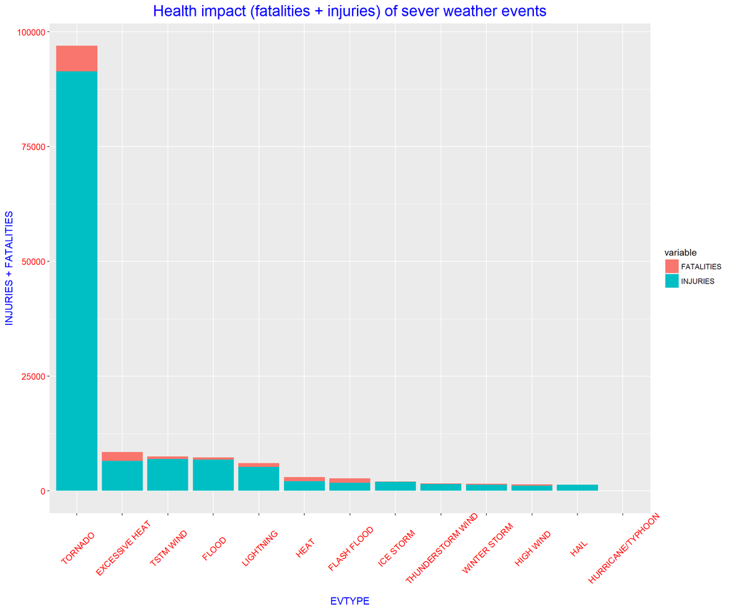

```r
storm_damage_health <- storm_damage %>% select(EVTYPE, FATALITIES, INJURIES) %>% mutate(TOTHLTHDMG = FATALITIES + INJURIES) %>% filter(TOTHLTHDMG > 0)

storm_damage_health_m <- storm_damage_health %>% melt(id=c("EVTYPE","TOTHLTHDMG"))

g <- ggplot(storm_damage_health_m[order(-storm_damage_health_m$TOTHLTHDMG),][1:25,], aes(x= reorder(EVTYPE,-TOTHLTHDMG), y=value, fill=variable)) + geom_col()
g <- g +  theme(axis.text.x=element_text(angle=45, vjust=0.6)) + xlab("EVTYPE") + ylab("INJURIES + FATALITIES")
g <- g + ggtitle("Health impact (fatalities + injuries) of sever weather events")
g <- g + theme(axis.text = element_text(size=10, color="red"))
g <- g + theme(axis.title = element_text(size=12, color="blue"))
g <- g + theme(plot.title=element_text(color="blue", size= 18, hjust=0.5))

print(g)
```

```r
storm_damage_health <- storm_damage_health %>% arrange(desc(TOTHLTHDMG))

head(storm_damage_health, 15)
```

```
# A tibble: 15 x 4
              EVTYPE FATALITIES INJURIES TOTHLTHDMG
              <fctr>      <dbl>    <dbl>      <dbl>
 1           TORNADO       5633    91346      96979
 2    EXCESSIVE HEAT       1903     6525       8428
 3         TSTM WIND        504     6957       7461
 4             FLOOD        470     6789       7259
 5         LIGHTNING        816     5230       6046
 6              HEAT        937     2100       3037
 7       FLASH FLOOD        978     1777       2755
 8         ICE STORM         89     1975       2064
 9 THUNDERSTORM WIND        133     1488       1621
10      WINTER STORM        206     1321       1527
11         HIGH WIND        248     1137       1385
12              HAIL         15     1361       1376
13 HURRICANE/TYPHOON         64     1275       1339
14        HEAVY SNOW        127     1021       1148
15          WILDFIRE         75      911        986
```

The above table and the graphics just before it show some of the top weather events in terms of the number of deaths and injuries that they cause.